# JALLOW_CHERNO_HW2P2

### Homework 2: More Exploratory Data Analysis

## Gene Expression Data and Election Polls

Due: Thursday, September 29, 2016 11:59 PM

#### Submission Instructions

To submit your homework, create a folder named **lastname_firstinitial_hw#** and place your IPython notebooks, data files, and any other files in this folder. Your IPython Notebooks should be completely executed with the results visible in the notebook. We should not have to run any code. Make sure to share the private repo with my github account (mdog) and submit the repo path through blackboard.

## Introduction

John Tukey wrote in [Exploratory Data Analysis, 1977](http://www.amazon.com/Exploratory-Data-Analysis-Wilder-Tukey/dp/0201076160/ref=pd_bbs_sr_2/103-4466654-5303007?ie=UTF8&s=books&qid=1189739816&sr=8-2): "The greatest value of a picture is when it forces us to notice what we never expected to see." In this assignment we will continue using our exploratory data analysis tools, but apply it to new sets of data: [gene expression](http://en.wikipedia.org/wiki/Gene_expression) and polls from the [2012 Presidental Election](http://en.wikipedia.org/wiki/United_States_presidential_election,_2012) and from the [2014 Senate Midterm Elections](http://en.wikipedia.org/wiki/United_States_Senate_elections,_2014).

**First**: You will use exploratory data analysis and apply the [singular value decomposition](http://en.wikipedia.org/wiki/Singular_value_decomposition) (SVD) to a gene expression data matrix to determine if the the date that the gene expression samples are processed has large effect on the variability seen in the data.

**Second**: You will use the polls from the 2012 Presidential Elections to determine (1) Is there a pollster bias in presidential election polls? and (2) Is the average of polls better than just one poll?

**Finally**: You will use the [HuffPost Pollster API](http://elections.huffingtonpost.com/pollster/api) to extract the polls for the current 2014 Senate Midterm Elections and provide a preliminary prediction of the result of each state.

#### Data

We will use the following data sets:

1. A gene expression data set called `exprs_GSE5859.csv` and sample annotation table called `sampleinfo_GSE5859.csv` which are both available on Github in the 2014_data repository: [expression data set](https://github.com/cs109/2014_data/blob/master/exprs_GSE5859.csv) and [sample annotation table](https://github.com/cs109/2014_data/blob/master/sampleinfo_GSE5859.csv).
2. Polls from the [2012 Presidential Election: Barack Obama vs Mitt Romney](http://elections.huffingtonpost.com/pollster/2012-general-election-romney-vs-obama). The polls we will use are from the [Huffington Post Pollster](http://elections.huffingtonpost.com/pollster).
3. Polls from the [2014 Senate Midterm Elections](http://elections.huffingtonpost.com/pollster) from the [HuffPost Pollster API](http://elections.huffingtonpost.com/pollster/api).

## Load Python modules

```python
# special IPython command to prepare the notebook for matplotlib
%matplotlib inline

import requests
from io import StringIO
from io import BytesIO
import numpy as np
import pandas as pd # pandas
import matplotlib.pyplot as plt # module for plotting
import datetime as dt # module for manipulating dates and times
import numpy.linalg as lin # module for performing linear algebra operations
```

## Problem 2: Is there a pollster bias in presidential election polls?

#### Problem 2(a)

The [HuffPost Pollster](http://elections.huffingtonpost.com/pollster) contains many political polls. You can access these polls from individual races as a CSV but you can also access polls through the [HuffPost Pollster API](http://elections.huffingtonpost.com/pollster/api) to access the data.

Read in the polls from the [2012 Presidential Election: Barack Obama vs Mitt Romney](http://elections.huffingtonpost.com/pollster/2012-general-election-romney-vs-obama) into a pandas DataFrame called `election`. For this problem, you may read in the polls for this race directly using [the CSV file](http://elections.huffingtonpost.com/pollster/2012-general-election-romney-vs-obama.csv) available from the HuffPost Pollster page.

```python
url = 'http://elections.huffingtonpost.com/pollster/2012-general-election-romney-vs-obama.csv'
request = requests.get(url)
election = pd.read_csv(BytesIO(request.content))
```

Show the head of the `election` DataFrame.

```python
election.head()
```

|  | Pollster | Start Date | End Date | Entry Date/Time (ET) | Number of Observations | Population | Mode | Obama | Romney | Undecided | Other | Pollster URL | Source URL | Partisan | Affiliation | Question Text | Question Iteration |
| --- | --- | --- | --- | --- | --- | --- | --- | --- | --- | --- | --- | --- | --- | --- | --- | --- | --- |
| 0 | Politico/GWU/Battleground | 2012-11-04 | 2012-11-05 | 2012-11-06T08:40:26Z | 1000.0 | Likely Voters | Live Phone | 47.0 | 47.0 | 6.0 | NaN | http://elections.huffingtonpost.com/pollster/p... | http://www.politico.com/news/stories/1112/8338... | Nonpartisan | None | NaN | 1 |
| 1 | YouGov/Economist | 2012-11-03 | 2012-11-05 | 2012-11-26T15:31:23Z | 740.0 | Likely Voters | Internet | 49.0 | 47.0 | 3.0 | NaN | http://elections.huffingtonpost.com/pollster/p... | http://cdn.yougov.com/cumulus_uploads/document... | Nonpartisan | None | NaN | 1 |
| 2 | Gravis Marketing | 2012-11-03 | 2012-11-05 | 2012-11-06T09:22:02Z | 872.0 | Likely Voters | Automated Phone | 48.0 | 48.0 | 4.0 | NaN | http://elections.huffingtonpost.com/pollster/p... | http://www.gravispolls.com/2012/11/gravis-mark... | Nonpartisan | None | NaN | 1 |
| 3 | IBD/TIPP | 2012-11-03 | 2012-11-05 | 2012-11-06T08:51:48Z | 712.0 | Likely Voters | Live Phone | 50.0 | 49.0 | NaN | 1.0 | http://elections.huffingtonpost.com/pollster/p... | http://news.investors.com/special-report/50841... | Nonpartisan | None | NaN | 1 |
| 4 | Rasmussen | 2012-11-03 | 2012-11-05 | 2012-11-06T08:47:50Z | 1500.0 | Likely Voters | Automated Phone | 48.0 | 49.0 | NaN | NaN | http://elections.huffingtonpost.com/pollster/p... | http://www.rasmussenreports.com/public_content... | Nonpartisan | None | NaN | 1 |

How many polls were conducted in November? Define this number as M.

**Hint**: Subset the `election` DataFrame for only dates in the `Start Date` column that are in November 2012.

```python
election_Nov_2012 = election[( (election['Start Date'] >= '2012-11-01') & (election['Start Date'] <= '2012-11-30'))]
```

```python
election_Nov_2012
```

|  | Pollster | Start Date | End Date | Entry Date/Time (ET) | Number of Observations | Population | Mode | Obama | Romney | Undecided | Other | Pollster URL | Source URL | Partisan | Affiliation | Question Text | Question Iteration |
| --- | --- | --- | --- | --- | --- | --- | --- | --- | --- | --- | --- | --- | --- | --- | --- | --- | --- |
| 0 | Politico/GWU/Battleground | 2012-11-04 | 2012-11-05 | 2012-11-06T08:40:26Z | 1000.0 | Likely Voters | Live Phone | 47.0 | 47.0 | 6.0 | NaN | http://elections.huffingtonpost.com/pollster/p... | http://www.politico.com/news/stories/1112/8338... | Nonpartisan | None | NaN | 1 |
| 1 | YouGov/Economist | 2012-11-03 | 2012-11-05 | 2012-11-26T15:31:23Z | 740.0 | Likely Voters | Internet | 49.0 | 47.0 | 3.0 | NaN | http://elections.huffingtonpost.com/pollster/p... | http://cdn.yougov.com/cumulus_uploads/document... | Nonpartisan | None | NaN | 1 |
| 2 | Gravis Marketing | 2012-11-03 | 2012-11-05 | 2012-11-06T09:22:02Z | 872.0 | Likely Voters | Automated Phone | 48.0 | 48.0 | 4.0 | NaN | http://elections.huffingtonpost.com/pollster/p... | http://www.gravispolls.com/2012/11/gravis-mark... | Nonpartisan | None | NaN | 1 |
| 3 | IBD/TIPP | 2012-11-03 | 2012-11-05 | 2012-11-06T08:51:48Z | 712.0 | Likely Voters | Live Phone | 50.0 | 49.0 | NaN | 1.0 | http://elections.huffingtonpost.com/pollster/p... | http://news.investors.com/special-report/50841... | Nonpartisan | None | NaN | 1 |
| 4 | Rasmussen | 2012-11-03 | 2012-11-05 | 2012-11-06T08:47:50Z | 1500.0 | Likely Voters | Automated Phone | 48.0 | 49.0 | NaN | NaN | http://elections.huffingtonpost.com/pollster/p... | http://www.rasmussenreports.com/public_content... | Nonpartisan | None | NaN | 1 |
| 5 | JZ Analytics/Newsmax | 2012-11-03 | 2012-11-05 | 2012-11-06T07:38:41Z | 1041.0 | Likely Voters | Internet | 47.0 | 47.0 | 6.0 | NaN | http://elections.huffingtonpost.com/pollster/p... | http://www.jzanalytics.com/ | Sponsor | Rep | NaN | 1 |
| 6 | UPI/CVOTER | 2012-11-03 | 2012-11-05 | 2012-11-05T18:30:15Z | 3000.0 | Likely Voters | Live Phone | 49.0 | 48.0 | NaN | NaN | http://elections.huffingtonpost.com/pollster/p... | NaN | Nonpartisan | None | NaN | 1 |
| 7 | Ipsos/Reuters (Web) | 2012-11-01 | 2012-11-05 | 2012-11-05T16:12:48Z | 4725.0 | Likely Voters | Internet | 48.0 | 46.0 | 4.0 | 2.0 | http://elections.huffingtonpost.com/pollster/p... | http://big.assets.huffingtonpost.com/ipsos1105... | Nonpartisan | None | NaN | 1 |
| 8 | ARG | 2012-11-02 | 2012-11-04 | 2012-11-05T13:06:54Z | 1200.0 | Likely Voters | Live Phone | 49.0 | 49.0 | 1.0 | 1.0 | http://elections.huffingtonpost.com/pollster/p... | http://americanresearchgroup.com/pres2012/NA12... | Nonpartisan | None | NaN | 1 |
| 9 | PPP (D-Americans United for Change) | 2012-11-02 | 2012-11-04 | 2012-11-04T22:32:19Z | 1200.0 | Likely Voters | Automated Phone | 50.0 | 48.0 | 3.0 | NaN | http://elections.huffingtonpost.com/pollster/p... | http://www.publicpolicypolling.com/pdf/2011/PP... | Sponsor | Dem | NaN | 1 |
| 10 | CNN | 2012-11-02 | 2012-11-04 | 2012-11-04T20:16:09Z | 693.0 | Likely Voters | Live Phone | 49.0 | 49.0 | 2.0 | NaN | http://elections.huffingtonpost.com/pollster/p... | http://i2.cdn.turner.com/cnn/2012/images/11/04... | Nonpartisan | None | NaN | 1 |
| 11 | ABC/Post | 2012-11-01 | 2012-11-04 | 2012-11-05T16:56:22Z | 2345.0 | Likely Voters | Live Phone | 50.0 | 47.0 | 1.0 | 1.0 | http://elections.huffingtonpost.com/pollster/p... | http://www.washingtonpost.com/blogs/the-fix/wp... | Nonpartisan | None | NaN | 1 |
| 12 | Gallup | 2012-11-01 | 2012-11-04 | 2012-11-05T13:48:29Z | 2551.0 | Likely Voters | Live Phone | 48.0 | 49.0 | NaN | NaN | http://elections.huffingtonpost.com/pollster/p... | http://www.gallup.com/poll/157817/election-201... | Nonpartisan | None | NaN | 1 |
| 13 | DailyKos/SEIU/PPP (D) | 2012-11-01 | 2012-11-04 | 2012-11-05T13:31:31Z | 1300.0 | Likely Voters | Automated Phone | 50.0 | 48.0 | 2.0 | NaN | http://elections.huffingtonpost.com/pollster/p... | http://www.dailykos.com/weeklypolling/2012/11/1 | Sponsor | Dem | NaN | 1 |
| 14 | Monmouth | 2012-11-01 | 2012-11-04 | 2012-11-05T12:52:03Z | 1417.0 | Likely Voters | IVR/Live Phone | 48.0 | 48.0 | 2.0 | 2.0 | http://elections.huffingtonpost.com/pollster/p... | http://cms.monmouth.edu/assets/0/84/159/214748... | Nonpartisan | None | NaN | 1 |
| 15 | Democracy Corps (D) | 2012-11-01 | 2012-11-04 | 2012-11-05T09:41:50Z | 1080.0 | Likely Voters | Live Phone | 49.0 | 45.0 | NaN | 1.0 | http://elections.huffingtonpost.com/pollster/p... | http://big.assets.huffingtonpost.com/demcorpst... | Pollster | Dem | NaN | 1 |
| 16 | Angus-Reid | 2012-11-01 | 2012-11-03 | 2012-11-06T08:47:46Z | 1019.0 | Likely Voters | Internet | 51.0 | 48.0 | NaN | 1.0 | http://elections.huffingtonpost.com/pollster/p... | http://www.angus-reid.com/polls/47681/obama-ho... | Nonpartisan | None | NaN | 1 |
| 17 | NBC/WSJ | 2012-11-01 | 2012-11-03 | 2012-11-04T09:12:21Z | 1475.0 | Likely Voters | Live Phone | 48.0 | 47.0 | 3.0 | 2.0 | http://elections.huffingtonpost.com/pollster/p... | http://firstread.nbcnews.com/_news/2012/11/04/... | Nonpartisan | None | NaN | 1 |
| 20 | UPI/CVOTER | 2012-11-02 | 2012-11-02 | 2012-11-03T16:40:44Z | 1074.0 | Likely Voters | Live Phone | 49.0 | 48.0 | NaN | NaN | http://elections.huffingtonpost.com/pollster/p... | NaN | Nonpartisan | None | NaN | 1 |

```python
M = len(election_Nov_2012.values)
M
```

```
19
```

Answer: 19 polls were conducted with the possibility of a pollster conducting more than 1 poll in the same time frame

What was the median of the number of observations in the November polls? Define this quantity as N.

N = np.median(election_Nov_2012['Number of Observations'])

```python
N
```

```
1200.0
```

Answer: 1200 observations

#### Problem 2(b)

Using the median sample size $N$ from Problem 1(a), simulate the results from a single poll: simulate the number of votes for Obama out of a sample size $N$ where $p$ = 0.53 is the percent of voters who are voting for Obama.

**Hint**: Use the binomial distribution with parameters $N$ and $p$ = 0.53.

```python
p = 0.53
votes = np.random.binomial(N, p)
votes_percentage = np.ceil(votes/N  * 100)
print("The Number of votes Obama would have received are: "+ str(votes))
print("The Percentage of Obama votes is: "+ str(votes_percentage))
```

```
The Number of votes Obama would have received are: 638
The Percentage of Obama votes is: 54.0
```

Now, perform a Monte Carlo simulation to obtain the estimated percentage of Obama votes with a sample size $N$ where $N$ is the median sample size calculated in Problem 2(a). Let $p$=0.53 be the percent of voters are voting for Obama.

**Hint**: You will repeat the simulation above 1,000 times and plot the distribution of the estimated *percent* of Obama votes from a single poll. The results from the single poll you simulate is random variable and will be different every time you sample.

```python
import warnings
warnings.filterwarnings('ignore')
MC_simulations = [np.mean( np.random.binomial(1, p, size=N) ) for i in range(1000)]
print (MC_simulations[:12])
```

```
[0.51500000000000001, 0.51749999999999996, 0.51166666666666671, 0.52416666666666667, 0.54333333333333333, 0.52083333333333337, 0.52749999999999997, 0.53749999999999998, 0.50583333333333336, 0.50583333333333336, 0.52749999999999997, 0.53416666666666668]
```

Plot the distribution of the estimated percentage of Obama votes from your single poll. What is the distribution of the estimated percentage of Obama votes?

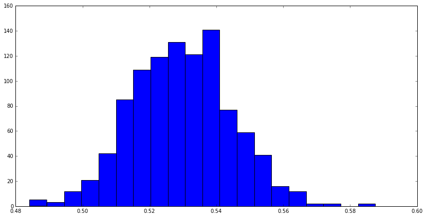

```python
plt.figure(figsize=(14,7))
plt.hist(MC_simulations , bins=20)
plt.show()
```

Answer: FAnswer:From the look of the histogram above, clearly it is a Normal Distribution because a bell curve could be traced.

What is the standard error (SE) of the estimated percentage from the poll.

**Hint**: Remember the SE is the standard deviation (SD) of the distribution of a random variable.

```python
np.std(MC_simulations)
```

```
0.014863765038209907
```

#### Problem 2(c)

Now suppose we run M polls where M is the number of polls that happened in November (calculated in Problem 2(a)). Run 1,000 simulations and compute the mean of the M polls for each simulation.

```python
Sim_M_Pol = [np.mean([np.mean( np.random.binomial(1, p, size=N) ) for i in range(M)]) for simulation in range(1000)]
Sim_M_Pol[:12]
```

```
[0.52864035087719297,
 0.52798245614035089,
 0.53096491228070186,
 0.53166666666666673,
 0.53337719298245623,
 0.531842105263158,
 0.52657894736842104,
 0.52868421052631565,
 0.53092105263157885,
 0.5301754385964913,
 0.52921052631578946,
 0.53039473684210514]
```

What is the distribution of the average of polls?

**Hint**: Show a plot.

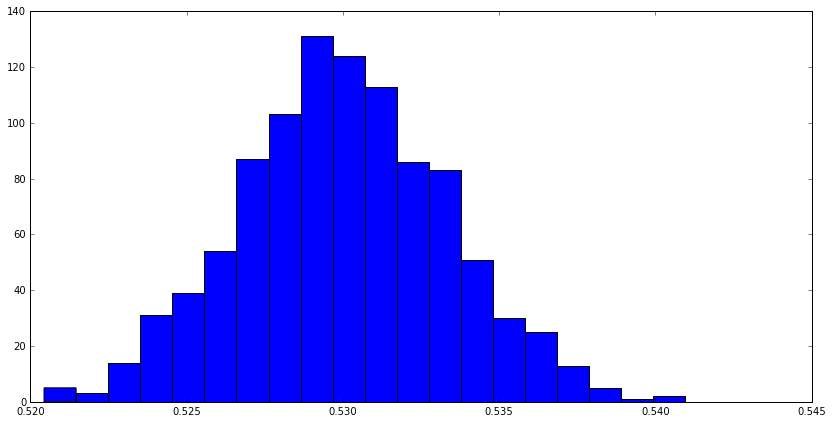

```python
from scipy.stats import norm
plt.figure(figsize=(14,7))
plt.hist(Sim_M_Pol , bins=20)
plt.show()
```

Answer:From the look of the histogram above, clearly it is a Normal Distribution because a bell curve could be traced.

What is the standard error (SE) of the average of polls?

```python
np.std(Sim_M_Pol)
```

```
0.0033125694981588462
```

Answer: 0.0033125694981588462

Is the SE of the average of polls larger, the same, or smaller than that the SD of a single poll (calculated in Problem 2(b))? By how much?

**Hint**: Compute a ratio of the two quantities.

```python
np.std(Sim_M_Pol)/np.std(MC_simulations)
```

```
0.22286207361616031
```

Answer: 0.22286207361616031

#### Problem 2(d)

Repeat Problem 2(c) but now record the *across poll* standard deviation in each simulation.

```python
Std = [np.std([np.mean( np.random.binomial(1, p, size=N) ) for i in range(M)]) for simulation in range(1000)]
Std[:12]
```

```
[0.0090195318308392558,
 0.014218104974985829,
 0.014365759237623905,
 0.016774466702362292,
 0.01138071270746094,
 0.014391847321092431,
 0.012944022056021272,
 0.0142078186720868,
 0.017236563097603505,
 0.015954908182317651,
 0.014294612604856771,
 0.016433151750479685]
```

What is the distribution of the *across M polls* standard deviation?

**Hint**: Show a plot.

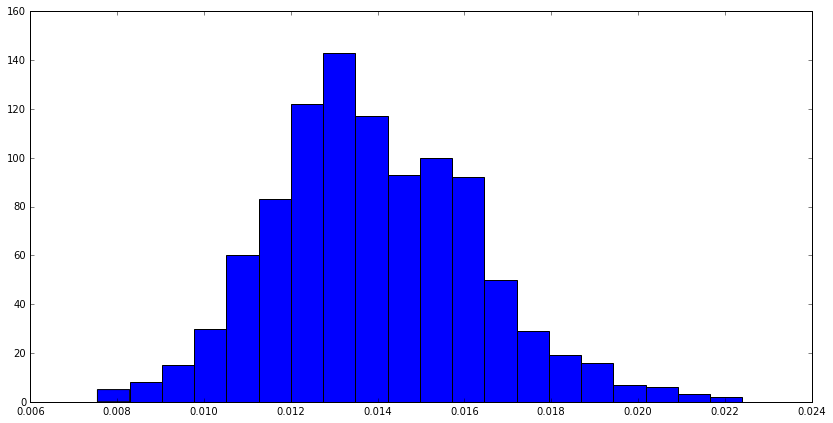

```python
plt.figure(figsize=(14,7))
plt.hist(Std , bins=20)
plt.show()
```

Answer: Answer:From the look of the histogram above, clearly it is a Normal Distribution because a bell curve could be traced.

#### Problem 2(e)

What is the standard deviation of M polls in our real (not simulated) 2012 presidential election data ?

```python
np.std(election_Nov_2012['Obama']/100.0)
```

```
0.010552598766191284
```

Is this larger, the same, or smaller than what we expeced if polls were not biased.

```python
np.mean(Std)
```

```
0.013933334455320063
```

Answer: Its is smaller

#### Problem 2(f)

Learn about the normal approximation for the binomial distribution and derive the results of Problem 2(b) and 2(c) analytically (using this approximation). Compare the results obtained analytically to those obtained from simulations.

```python
print("Std using simulations 2b: " + str(np.std(MC_simulations)))
print("Std using square root of the variance with N polls: " + str(np.sqrt(p * (1-p)/ N)))
```

```
Std using simulations 2b: 0.0148637650382
Std using square root of the variance with N polls: 0.0144077525428
```

```python
print("Std using simulations 2c: " + str(np.std(Sim_M_Pol)))
print("Std using square root of the variance with N*M polls: " + str(np.sqrt(p * (1-p)/ (N*M))))
```

```
Std using simulations 2c: 0.00331256949816
Std using square root of the variance with N*M polls: 0.00330536512302
```

Answer: The results obtained analytically vs the results obtained using a simulation is approximately the same

## Discussion for Problem 2

From the analysis conducted on November 2012 polls, the fact that the std is marginal, its fair to say that the polls are unbiased.